# Espacios con producto interno

Álgebra lineal.

# 1 Espacios con producto interno

Un **producto interno** en un espacio vectorial real $V$ es una función que a cada par de vectores $\mathbf{u}$ y $\mathbf{v}$ en $V$, le asigna un número real denotado por $\langle \mathbf{u}, \mathbf{v}\rangle$. Esta función satisface las siguientes propiedades: si $\mathbf{u}, \mathbf{v}$ y $\mathbf{w}$ son vectores y $c$ es un escalar, entonces

$a)$ $\langle \mathbf{u}, \mathbf{v}\rangle = \langle \mathbf{v}, \mathbf{u}\rangle$.

$b)$ $\langle \mathbf{u}, \mathbf{v}+\mathbf{w}\rangle = \langle \mathbf{u}, \mathbf{v}\rangle + \langle \mathbf{u}, \mathbf{w}\rangle$.

$c)$ $c\langle \mathbf{u}, \mathbf{v}\rangle = \langle c\mathbf{u}, \mathbf{v}\rangle$

$d)$ $\langle \mathbf{v}, \mathbf{v}\rangle \geq 0$, $\forall\,\, \mathbf{v}\in V$.

$e)$ $\langle \mathbf{v}, \mathbf{v}\rangle = 0$ si y sólo si $\mathbf{v}=\mathbf{0}$.

**Definición** Un espacio vectorial $V$ en el que hay definido un producto interno se denomina **espacio (vectorial real) con producto interno**.

Si por el contrario, tenemos un espacio vectorial complejo, es decir $\mathbb{K}=\mathbb{C}$, un **producto interno** $V$ es una función que a cada par de vectores $\mathbf{u}$ y $\mathbf{v}$ en $V$, le asigna un número **complejo** denotado por $\langle \mathbf{u}, \mathbf{v}\rangle$. Esta función satisface las siguientes propiedades: si $\mathbf{u}, \mathbf{v}$ y $\mathbf{w}$ son vectores y $c$ es un escalar, entonces

$a)$ $\langle \mathbf{v}, \mathbf{u}\rangle = \overline{\langle \mathbf{u}, \mathbf{v}\rangle}$.

$b)$ $\langle \mathbf{u}, \mathbf{v}+\mathbf{w}\rangle = \langle \mathbf{u}, \mathbf{v}\rangle + \langle \mathbf{u}, \mathbf{w}\rangle$.

$c)$ $\langle c\mathbf{u}, \mathbf{v}\rangle = c\langle \mathbf{u}, \mathbf{v}\rangle$

$d)$ $\langle \mathbf{v}, \mathbf{v}\rangle \geq 0$, $\forall\,\, \mathbf{v}\in V$.

$e)$ $\langle \mathbf{v}, \mathbf{v}\rangle = 0$ si y sólo si $\mathbf{v}=\mathbf{0}$.

**Definición** Un espacio vectorial $V$ en el que hay definido un producto interno se denomina **espacio (vectorial complejo) con producto interno**.

## 1.1 Ejemplo 1

Demuestre que en $\mathbb{R}^n$ el producto punto de dos vectores $\mathbf{u}=(u_1,\ldots,u_n)$ y $\mathbf{v}=(v_1,\ldots,v_n)$,
$$\langle \mathbf{u}, \mathbf{v}\rangle = \mathbf{u}\cdot
\mathbf{v} = u_1v_1 + \cdots + u_nv_n$$
es un producto interno en $\mathbb{R}^n$.

## 1.2 Ejemplo 2

Demuestre que en $\mathbb{R}^2$ la función que a los vectores $\mathbf{u}=(u_1,u_2)$ y $\mathbf{v}=(v_1,v_2)$ le asigna el número real
$$\langle \mathbf{u}, \mathbf{v}\rangle = u_1v_1 + 2u_2v_2$$
es un producto interno en $\mathbb{R}^2$.

## 1.3 Ejemplo 3

Mostrar que en $V=\mathbb{R}_3[x]$, la siguiente función $\langle , \rangle:V\times V \rightarrow \mathbb{R}$ $\langle p, q\rangle=\int_{-1}^1p(s)q(s)ds$ es un producto interno.

## 1.4 Ejemplo 4

Mostrar que en $V=\mathcal{M}^{n,n}(\mathbb{R})$, $\langle A,B \rangle = tr(AB^{T})$.
$$tr(AB^{T}) = \sum_{i=1}^n\sum_{j=1}^na_{ij}b_{ij}$$

## 1.6 Norma de un vector

Por medio del producto interno, podemos definir la norma de un vector.

**Definición** La norma inducida por el producto interno se define como
$$\begin{equation}
\|\mathtt{x}\| = \sqrt{\langle \mathtt{x}, \mathtt{x} \rangle}
\end{equation}$$

### 1.6.1 Propiedades de la norma

1. Para todo $\mathtt{x}\in V$, si $\|\mathtt{x}\|= \mathbf{0} \Leftrightarrow \mathtt{x}=\mathbf{0}$. Si $x\ne \mathbf{0}$ entonces $\|\mathtt{x}\| > 0$
2. Para todo $c\in \mathbb{R}$ y $\mathtt{x}\in V$
   $$\|c\cdot \mathtt{x}\| = |c|\|\mathtt{x}\|$$
3. Para todo $\mathtt{x},\mathtt{y}\in V$ se cumple la desigualdad de Cauchy-Schwarz
   $$|\langle \mathtt{x},\mathtt{y} \rangle|\leq \|\mathtt{x} \|\|\mathtt{y}
   \|$$
4. Para todo $\mathtt{x},\mathtt{y}\in V$
   $$\|\mathtt{x}+\mathtt{y}\|\leq \|\mathtt{x}\| + \|\mathtt{y}\|$$

## 1.7 Distancia entre vectores

Definimos la distancia entre vectores $\mathbf{x}$, $\mathbf{y}\in V$ tal que
$$d(\mathbf{x},\mathbf{y})=\|\mathbf{y}-\mathbf{x}\|$$

Derivado de las propiedades de la norma de vectores, la distancia entre 2 vectores, como función $d:V\times V\rightarrow \mathbb{R}$ se cumple que

**a)**

Para todo $\mathbf{x}\in V$ $d(\mathbf{x},\mathbf{x})=0$.

**b)**

Para todo $\mathbf{x},\mathbf{y}\in V$, $d(\mathbf{x},\mathbf{y})\geq 0$ y además $d(\mathbf{x},\mathbf{y})=0$ si y sólo si $\mathbf{x}=\mathbf{y}$

**c)**

Para todo $\mathbf{x},\mathbf{y},\mathbf{z}\in V$
$$d(\mathbf{x},\mathbf{y}) \leq
d(\mathbf{x},\mathbf{z})+d(\mathbf{z},\mathbf{y})$$

## 1.8 Ángulo entre vectores

*Definimos* al ángulo entre dos vectores, $\mathbf{x},\mathbf{y}\in V$ como
$$\cos\theta = \frac{\langle \mathbf{x},
\mathbf{y}\rangle}{\|\mathbf{x}\|\|\mathbf{y}\|}$$

## 1.9 Ortogonalidad

Por tanto, dos vectores formarán un *ángulo* de $90°$ si $\cos \theta=0$ es decir $\theta= \pm \frac{\pi}{2}+2\pi k$, esto ocurre sólo si $\langle \mathbf{x},\mathbf{y}\rangle = 0$.

**Ortogonalidad** Sea $V$ un espacio vectorial con producto interno, decimos que dos vectores son **ortogonales** si
$$\begin{equation}
\langle \mathbf{x}, \mathbf{y} \rangle =0
\end{equation}$$

Igualmente, un conjunto de vectores $U=\{v_1,v_2,\ldots,v_k\}$ es un conjunto de vectores **ortogonales** si toda pareja de vectores $\mathbf{v}_i\in U$ y $\mathbf{v}_j\in U$ son ortogonales es decir

$$\langle v_i, v_j \rangle = \begin{cases}
0 & i\ne j\\
\|v_i\|^2 & i=j
\end{cases}$$

Por último, un conjunto de vectores finitos $U=\{v_1,v_2,\ldots, v_k\}$ se dice ser **ortonormal** si

$$\begin{equation}
\langle v_i , v_i \rangle = \begin{cases}
0 & \mbox{si }\,
i\ne j \\
1 & \mbox{si }\, i =
j
\end{cases}
\end{equation}$$

### 1.9.1 Proposición

Si $U$ es un conjunto de vectores *ortogonales* entonces es un conjunto de vectores **linealmente** **independiente**. Suponga que $\sum_i \alpha_i\mathbf{v}_i=\mathbf{0}$ entonces tomando el producto interno, con $\mathbf{v}_i$ tenemos que
$$0=\langle \mathbf{0}, \mathbf{v}_i \rangle = \langle
\sum_{k}\alpha_k\mathbf{v}_k, \mathbf{v}_i\rangle =
\alpha_i\|\mathbf{v}_i\|^2$$
Como $\mathbf{v}_i$ es un elemento de un conjunto de vectores linealmente independiente entonces $\mathbf{v}_i\ne 0$ (¿por que?) y esto implica que $\alpha_i=0$

### 1.9.2 Proposición

Si $U$ es un conjunto de vectores generadores de $V$ que son ortogonales entonces
$$\mathbf{v}=\sum_{i=1}^n \frac{\langle \mathbf{v},\mathbf{v}_i
\rangle}{\|\mathbf{v}_i\|^2}\mathbf{v}_i$$

En efecto, si $U$ es un conjunto generador de $V$ y $U$ es un conjunto de vectores ortogonales, como $U$ genera a $V$ entonces para todo $v\in V$ y $\mathbf{v}_1,\mathbf{v}_2,\ldots,\mathbf{v}_j \in U$
$$\mathbf{v}=\alpha_1 \mathbf{v}_1 + \alpha_2 \mathbf{v}_2 + \ldots +
\alpha_j \mathbf{v}_j$$
Entonces, si tomamos el producto interno por $\mathbf{v}_j$
$$\begin{matrix}
\langle \mathbf{v}, \mathbf{v}_j \rangle & = &
\langle \alpha_1 \mathbf{v}_1 + \alpha_2 \mathbf{v}_2 + \ldots +
\alpha_j \mathbf{v}_j, \mathbf{v}_j \rangle \\
\langle \mathbf{v}, \mathbf{v}_j \rangle & = &
\sum_{i=1}^{j}\alpha_i \langle \mathbf{v}_i ,\mathbf{v}_j\rangle \\
\langle \mathbf{v}, \mathbf{v}_j \rangle & = & \alpha_j
\|\mathbf{v}_j\|^2
\end{matrix}$$
Entonces, los escalares de la combinación lineal están dados por
$$\alpha_j = \frac{\langle
\mathbf{v},\mathbf{v}_j \rangle}{\|\mathbf{v}_j\|^2}$$

### 1.9.3 Complemento ortogonal

Sea $U$ un conjunto de vectores en $V$, un espacio con producto interno. Definimos al complemento ortogonal de $U$ como

$$\begin{equation}
U^{\perp} =\big\{ \mathtt{v}\in V\,\, \left\langle \mathtt{v},
\mathtt{u}\right\rangle=0,\mbox{ para todo }u\in U\big\}
\end{equation}$$

- Proposición.
- $U^{\perp}$ es un subespacio vectorial.
- Si $U$ es un subespacio vectorial entonces

$$V = U \bigoplus U^{\perp}$$

## 1.10 Desigualdad de Bessel

Si $U=\{\mathtt{v}_1,\mathtt{v}_2,\ldots, \mathtt{v}_k\}$ son ortogonales y $\mathtt{v}\in V$ entonces
$$\sum_{i=1}^{k}\frac{|\left\langle \mathtt{v}, \mathtt{v}_i
\right\rangle|^2}{\|\mathtt{v}_i\|^2} \leq \|\mathtt{v}\|^2$$

### 1.10.1 Ejemplo de bases ortogonales y ortonormales

Sea $V=\mathbb{R}^{3}$ y

$$\begin{array}{ccc}
\mathbf{v}_1 =
\begin{pmatrix} 1 \\ 2 \\ -1 \end{pmatrix}, &
\mathbf{v}_2 =
\begin{pmatrix} 0 \\ 1 \\ 2 \end{pmatrix}, &
\mathbf{v}_3 =
\begin{pmatrix} 5 \\ -2 \\ 1 \end{pmatrix}
\end{array}$$

Los vectores son ortogonales $\mathbf{v}_1\bullet \mathbf{v}_2 = 1\cdot 0 + 2\cdot 1 + (-1)\cdot 2=0$, similarmente, $\mathbf{v}_1\bullet \mathbf{v}_3 = 1\cdot 5 + 2\cdot(-2) + (-1)\cdot 1=0$ y $\mathbf{v}_2\bullet \mathbf{v}_3 = 0\cdot 5 + 1\cdot (-2) + 2\cdot 1=0$.

La norma de los vectores $\|\mathbf{v}_1\|=\sqrt{1^2 + 2^2 + (-1)^2}=\sqrt{6}$, $\|\mathbf{v}_2\|=\sqrt{0^2 + 1^2 + 2^2}=\sqrt{5}$ y $\|\mathbf{v}_3\|=\sqrt{5^2 + (-2)^2 + 1^2}=\sqrt{30}$.

Por las propiedades de los conjuntos ortogonales, tenemos a 3 vectores linealmente independientes, por tanto forman una base de $\mathbb{R}^3$.

Una base ortonormal sería

$$\begin{array}{ccc}
\hat{\mathbf{v}}_1 =
\begin{pmatrix}
1/\sqrt{6} \\ 2/\sqrt{6} \\ -1/\sqrt{6} \end{pmatrix},
&
\hat{\mathbf{v}}_2 =
\begin{pmatrix}
0 \\ 1/\sqrt{5} \\ 2/\sqrt{5} \end{pmatrix}, &
\hat{\mathbf{v}}_3 =
\begin{pmatrix}
5/\sqrt{30} \\ -2/\sqrt{30} \\ 1/\sqrt{30}
\end{pmatrix}
\end{array}$$

## 1.11 Proyección ortogonal sobre un vector

Si $w$ es un vector definimos la *proyección* *ortogonal* de $\mathbf{v}$ sobre $\mathbf{w}$ como
$$P_w\mathbf{v}= \frac{\langle \mathbf{v},
\mathbf{w}\rangle}{\|\mathbf{w}\|^2}\mathbf{w}$$

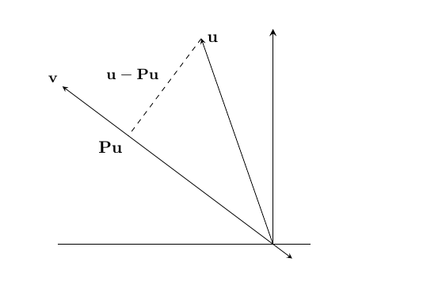

## 1.12 Proceso de ortogonalización de Gramm-Schmidt

Es fácil ver, como en el ejemplo anterior, que en $\mathbb{R}^n$ existen bases $ortogonales$ y *ortonormales*. ¿Se cumple para un espacio vectorial $V$ arbitrario, finitamente generado?

Se busca obtener la existencia de una base de vectores ortonormales de un espacio vectorial. Sabemos que si $V$ es un espacio vectorial finitamente generado, entonces existe una base $\mathcal{B}$. ¿Siempre existe una base de vectores *ortonormales*?

El proceso de ortogonalización da una respuesta afirmativa y un procedimiento para calcular una base ortonormal a partir de una base de vectores.

Sea $\mathcal{B}=\{v_1,v_2,\ldots,v_n\}$ una base ordenada de $V$.

Definimos a los siguientes vectores
$$w_1=v_1,$$

$$w_2 = v_2 - P_{w_1}v_2 = v_2 - \frac{\langle v_2,w_1 \rangle}{\langle
w_1,w_1 \rangle}w_1,$$

$$w_{n-1} = v_{n-1} - \sum^{n-2}_{k=1} P_{w_k}v_{n-1} = v_{n-1} -
\frac{\langle v_{n-1},w_1 \rangle}{\langle w_1,w_1 \rangle}w_1-
\frac{\langle v_{n-1},w_2 \rangle}{\langle w_2,w_2 \rangle}w_2 \ldots -
\frac{\langle v_{n-1},w_{n-2} \rangle}{\langle w_{n-2},w_{n-2}
\rangle}w_{n-2},$$

$$w_{n} = v_{n} - \sum^{n-1}_{k=1} P_{w_k}v_{n} = v_{n} - \frac{\langle
v_{n},w_1 \rangle}{\langle w_1,w_1 \rangle}w_1- \frac{\langle v_{n},w_2
\rangle}{\langle w_2,w_2 \rangle}w_2 \ldots - \frac{\langle
v_{n},w_{n-1} \rangle}{\langle w_{n-1},w_{n-1} \rangle}w_{n-1},$$

Posteriormente, la base **ortonormal** $\mathcal{O}=\{\mathbf{y}_1,\mathbf{y}_2,\ldots , \mathbf{y}_n\}$ está dada por
$$\mathbf{y}_i = \frac{w_i}{\|w_i\|}$$

## 1.13 Proposición

*Los* *vectores* $\mathbf{w}_i$ *son ortogonales a los vectores* $\mathbf{w}_1,\mathbf{w}_2,\ldots,\mathbf{w}_{i-1}$.

Por hipótesis de inducción, supondremos que $\mathbf{w}_{i-1}$ es ortogonal a los vectores $\mathbf{w}_1,\mathbf{w}_2,\ldots,\mathbf{w}_{i-2}$, entonces por la linealidad del producto interno si $i\ne j$
$$\langle w_i, w_j \rangle = \biggl< \mathbf{v}_{i} - \sum_{k=1}^{n}
\frac{\langle \mathbf{v}_{i}, \mathbf{w}_{k}
\rangle}{\|\mathbf{w}_k\|^2}\mathbf{w}_k,\mathbf{w}_j\biggr>= \langle
\mathbf{v}_i, \mathbf{w}_j \rangle - \sum_{k=1}^n \frac{\langle
\mathbf{v}_{i}, \mathbf{w}_{k} \rangle}{\|\mathbf{w}_k\|^2}\langle
\mathbf{w}_k, \mathbf{w}_j \rangle$$
$$\langle w_i, w_j \rangle = \langle \mathbf{v}_i, \mathbf{w}_j \rangle -
\frac{\langle \mathbf{v}_{i}, \mathbf{w}_{j}
\rangle}{\|\mathbf{w}_j\|^2}\langle \mathbf{w}_j, \mathbf{w}_j \rangle=0$$

## 1.14 Teorema.

Sea $V$ un espacio vectorial de dimensión finita. Suponga que $v_1,\ldots,v_m$ es una lista de vectores linealmente independientes en $V$. Definimos
$$\begin{matrix}
\mathbf{w}_1=\mathbf{v}_1, &\quad\quad &
\mathbf{w}_2=\mathbf{v}_2 - \frac{\langle \mathbf{v}_2, \mathbf{w}_1
\rangle}{\|\mathbf{w}_1\|^2}\mathbf{w}_1, \\
\ldots & \quad\quad & \ldots \\
\mathbf{w}_m= \mathbf{v}_m - \sum_{k=1}^{m-1}\frac{\langle\mathbf{v}_n,
\mathbf{w}_k\rangle}{\|\mathbf{w}_k\|^2}\mathbf{w}_{k}
\end{matrix}$$
$$\begin{equation}
\mathbf{y}_i=\frac{\mathbf{w}_i}{\|\mathbf{w}_i\|},\mbox{ para todo
}i=1,\ldots,m
\end{equation}$$

Entonces $\{\mathbf{u}_1,\mathbf{u}_2,\ldots, \mathbf{u}_m\}$ es una lista de vectores ortonormales en $V$. Y además
$$\mathcal{S}(\mathbf{v}_1,\mathbf{v}_2,\ldots, \mathbf{v}_m) =
\mathcal{S}(\mathbf{y}_1,\mathbf{y}_2,\ldots, \mathbf{y}_m)$$

En particular, todo espacio vectorial de dimensión finita con producto interno tiene una base de vectores *ortonormales*.

### 1.14.1 Ejemplo

1. Usar el proceso de ortogonalización de Gram-Schmidt para determinar una base ortonormal de $\mathbb{R}^3$, a partir de los siguientes vectores
   $$\begin{Bmatrix}
   \begin{pmatrix}1\\ 1 \\ 0 \end{pmatrix},
   \begin{pmatrix}0\\ 1 \\-1 \end{pmatrix},
   \begin{pmatrix}1\\ 0 \\-1 \end{pmatrix}
   \end{Bmatrix}$$
2. Usa el proceso de ortogonalización de Gram-Schmidt para determinar una base ortogonal a partir de
   $$\begin{Bmatrix}
   \begin{pmatrix} 1\\ 2 \\ 3 \end{pmatrix},
   \begin{pmatrix} 4\\ 5 \\ 0 \end{pmatrix},
   \begin{pmatrix} 2\\ 3 \\-1 \end{pmatrix}
   \end{Bmatrix}$$
3. Encuentra una base ortonormal para el subespacio generado por los vectores
   $$\begin{Bmatrix}
   \begin{pmatrix} 0\\ 2 \\ 1 \end{pmatrix},
   \begin{pmatrix} 1\\ -2 \\ 1 \end{pmatrix}
   \end{Bmatrix}$$

Solución a)
$$\mathbf{w}_1=\begin{pmatrix} 1 \\ 1 \\ 0 \end{pmatrix}$$
entonces
$$\mathbf{w}_2=\begin{pmatrix} 0 \\ 1 \\ -1 \end{pmatrix} -
\frac{(0,1,-1)\cdot(1,1,0)}{(1,1,0)\cdot (1,1,0)}\begin{pmatrix} 1\\ 1
\\ 0\end{pmatrix} =\begin{pmatrix} 0 \\ 1 \\ -1 \end{pmatrix} -
\frac{1}{2}\begin{pmatrix} 1\\ 1 \\ 0\end{pmatrix} =
\begin{pmatrix} -1/2\\ 1/2 \\ -1\end{pmatrix}$$

# 2 Ejemplos

1. Sea $V=\mathbb{R}^4$ y $\left \langle \mathtt{x}, \mathtt{y}\right \rangle = \mathtt{x} \cdot \mathtt{y}$, el producto punto. Sea
   $$\mathtt{\vec{x}} =\begin{pmatrix} -4 \\ 2 \\ 1 \\2 \end{pmatrix},
   \quad\quad \mathtt{\vec{y}} =\begin{pmatrix} 1 \\ 0 \\ 2 \\2
   \end{pmatrix}$$
   Calcula el ángulo entre los vectores $\mathtt{\vec{x}}$ y $\mathtt{\vec{y}}$.
2. Calcula el ángulo entre los vectores
- $\mathtt{u}_1=(1,1,1,1),\,\, \mathtt{u}_2=(1,1,1,-1)$.
- $\mathtt{u}_1=(1,1,1,1),\,\, \mathtt{u}_2=(1,-1,-1,-1)$.
- $\mathtt{u}_1=(1,\sqrt{2},1,0),\,\, \mathtt{u}_2=(0,1,\sqrt{2},1)$.
3. Ejemplo. Sea $V=\mathbb{R}_2[x]$ y $f(x)=x^2 + x + 1$, $g(x)=3x+2$. Calcular $\left \langle f,g \right\rangle$, $\|f\|$, $\|g\|$ y el ángulo entre los dos polinomios.
4. Sea $V=\mathbb{R}^3$ y
   $$\mathcal{B}=
   \begin{Bmatrix}
   \mathtt{\vec{u}}_1 = \begin{pmatrix} 1/\sqrt{2} \\ -1/\sqrt{2} \\
   0 \end{pmatrix}, \mathtt{\vec{u}}_2 =\begin{pmatrix} 1/\sqrt{3} \\
   1/\sqrt{3} \\ 1/\sqrt{3} \end{pmatrix},\,\,
   \mathtt{u}_3=\begin{pmatrix} -1/\sqrt{6} \\ -1/\sqrt{6} \\
   2/\sqrt{6} \end{pmatrix}
   \end{Bmatrix}$$
- Demostrar que es una base ortonormal.
- Escribir a $\vec{x}=\begin{pmatrix} -1 \\ 2 \\ 1 \end{pmatrix}$ como combinación lineal de $\mathcal{B}$.
5. Sea $\vec{v}=(6,7)\in\mathbb{R}^2$ y $\left \langle \vec{x}, \vec{y} \right \rangle_B = 2x_1y_1 -3x_1y_2-3x_2y_1 + 2x_2y_2$, calcular
- Si $\mathtt{e}_1 = (1,0)$ y $\mathtt{e}_2 = (0,1)$, calcular $\left \langle \mathtt{e}_1, \mathtt{e}_2 \right \rangle_B$, $\|\mathtt{e}_1\|_B$, $\|\mathtt{e}_2\|_B$.
- Calcular los cosenos directores de $\vec{v}=(6,7)$ con respecto a ese producto interno.
6. Sea $\mathtt{u}_1=\begin{pmatrix} 1 \\ 0 \\ 0 \end{pmatrix},\,$ $\mathtt{u}_2=\begin{pmatrix} 1 \\ 1 \\ 0 \end{pmatrix},\,$ $\mathtt{u}_3=\begin{pmatrix} 1 \\ 1 \\ 1 \end{pmatrix}$ .
- Obtener un conjunto de vectores ortogonales, aplicando Gram-Schmidt.
- Obtener una base ortonormal.
7. Determinar si $\mathcal{B} = \{\mathtt{u}=(1,2,1)$, $\mathtt{v}=(1,-1,1)$ y $\mathtt{w}=(-1,1,2) \}$.
- Calcular las normas de los vectores con respecto a la norma inducida por el producto punto.
- Determinar si los vectores forman una base.
- Encontrar una base ortonormal de $\mathbb{R}^3$.
8. Sea
   $$\mathcal{H}=\begin{Bmatrix} \mathtt{\vec{v}}_1 = \begin{pmatrix} 1 \\
   -1 \\ 1 \end{pmatrix},\,\, \mathtt{\vec{v}}_2 = \begin{pmatrix} -2 \\
   3 \\ -1 \end{pmatrix},\,\, \mathtt{\vec{v}}_3 = \begin{pmatrix} -3 \\
   5 \\ -1 \end{pmatrix},\,\, \mathtt{\vec{v}}_4 = \begin{pmatrix} 1 \\ 2
   \\ -4 \end{pmatrix} \end{Bmatrix}$$
   A partir de $\mathcal{H}$ construir una base ortonormal.
9. Usar el proceso de Gram- Schmidt para obtener una base ortonormal de $\mathbb{R}^3$ a partir de

$$\mathcal{B} = \begin{Bmatrix} \begin{pmatrix} 1 \\ 2 \\3 \end{pmatrix},
\,\, \begin{pmatrix} 4 \\ 5 \\0 \end{pmatrix},\,\, \begin{pmatrix} 2
\\ 3 \\-1 \end{pmatrix} \end{Bmatrix}$$

10. Encontrar una base *ortonormal* al subespacio generado por $\{\mathtt{v}_1=(1,1,-1),\mathtt{v}_2=(1,0,1)\}$
11. Encontrar una base *ortonormal* al subespacio generado por $\{\mathtt{v}_1=(1,2,1,0),\mathtt{v}_2=(1,2,3,1)\}$